# MP_SRF_amplicons_18S_and_16S_diversity_analysis

### 2.3.3) Index of evenness

#### 2.3.3.1) Pielou’s index

```r
pielou_evenness_16S_tax_occur_ss5836 <- tb16_tax_occur_ss5836_div/log(OTUs_per_sample_16S_tax_occur_ss5836)
```

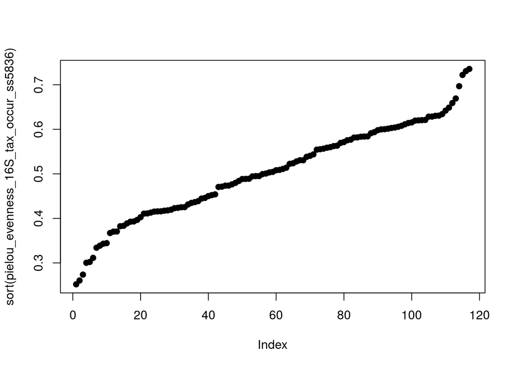

```r
plot(sort(pielou_evenness_16S_tax_occur_ss5836), pch=19)
```

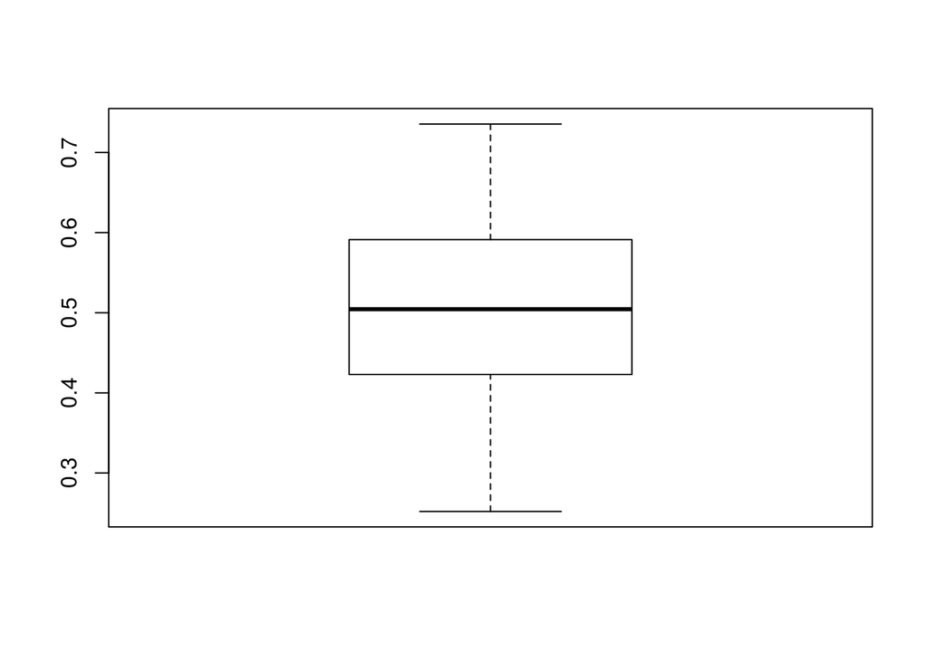

```r
boxplot(pielou_evenness_16S_tax_occur_ss5836, pch=19)
```

```r
head(sort(colSums(tb16_tax_occur_ss5836_no_cero), decreasing=T), n=10L)
```

```
##   OTU_1   OTU_2   OTU_4   OTU_5   OTU_3   OTU_6 OTU_552  OTU_10  OTU_23
##  277010   97628   34553   26999   12085   11019    7175    6737    6383
## OTU_435
##    6063
```

Most of the OTUs show very few occurrences; the plot suggests that we will probably be able to identify a significant ammount of rare otus:

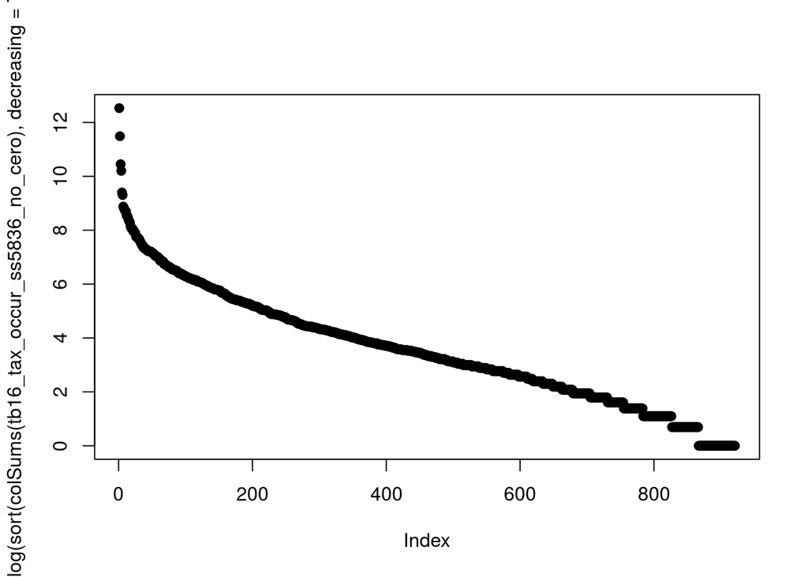

```r
plot(log(sort(colSums(tb16_tax_occur_ss5836_no_cero), decreasing=T)), pch=19)
```

### 2.3.4) Abundance Models

#### 2.3.4.1) Rank-Abundance or Dominance/Diversity Model (“radfit”)

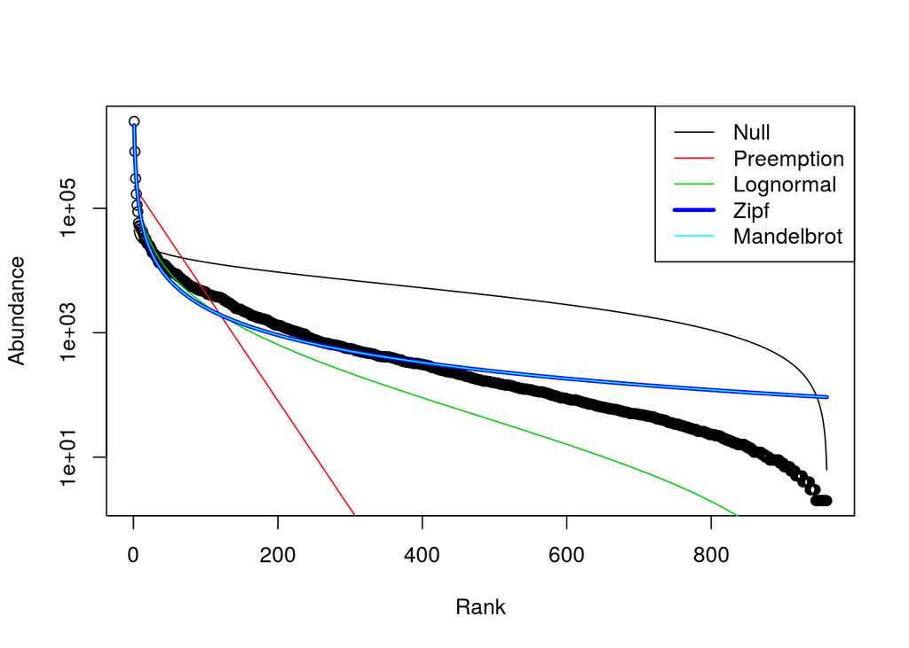

#### 2.3.4.2) Preston’s Lognormal Model

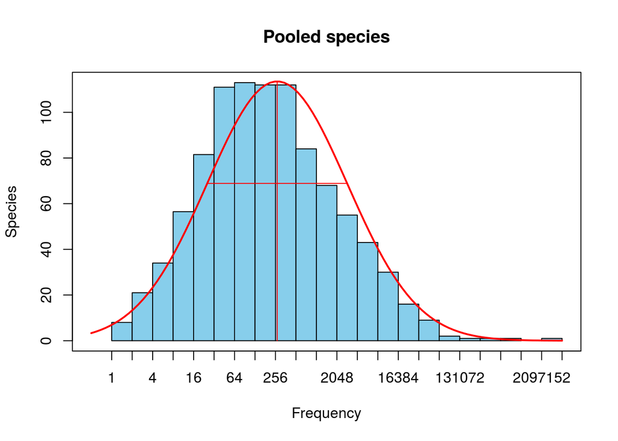

```r
tb16_tax_occur_ss5836_prestonfit<-prestonfit(colSums(tb16_tax_occur_min5836_t))
plot(tb16_tax_occur_ss5836_prestonfit, main="Pooled species")
```

```r
veiledspec(tb16_tax_occur_ss5836_prestonfit)
```

```
## Extrapolated     Observed       Veiled
##    972.72511    960.00000     12.72511
```

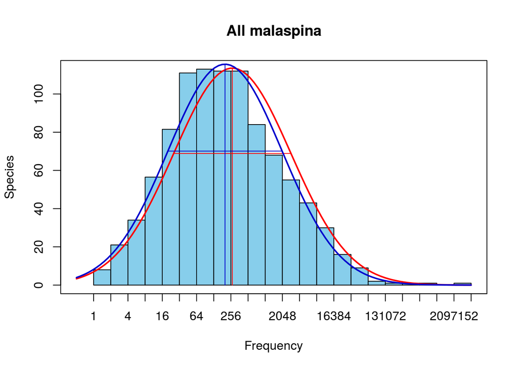

```
## Extrapolated     Observed       Veiled
##   964.490456   960.000000     4.490456
```

### 2.3.6) Beta diversity

#### 2.3.6.1) Dissimilarity matrix using Bray-Curtis index:

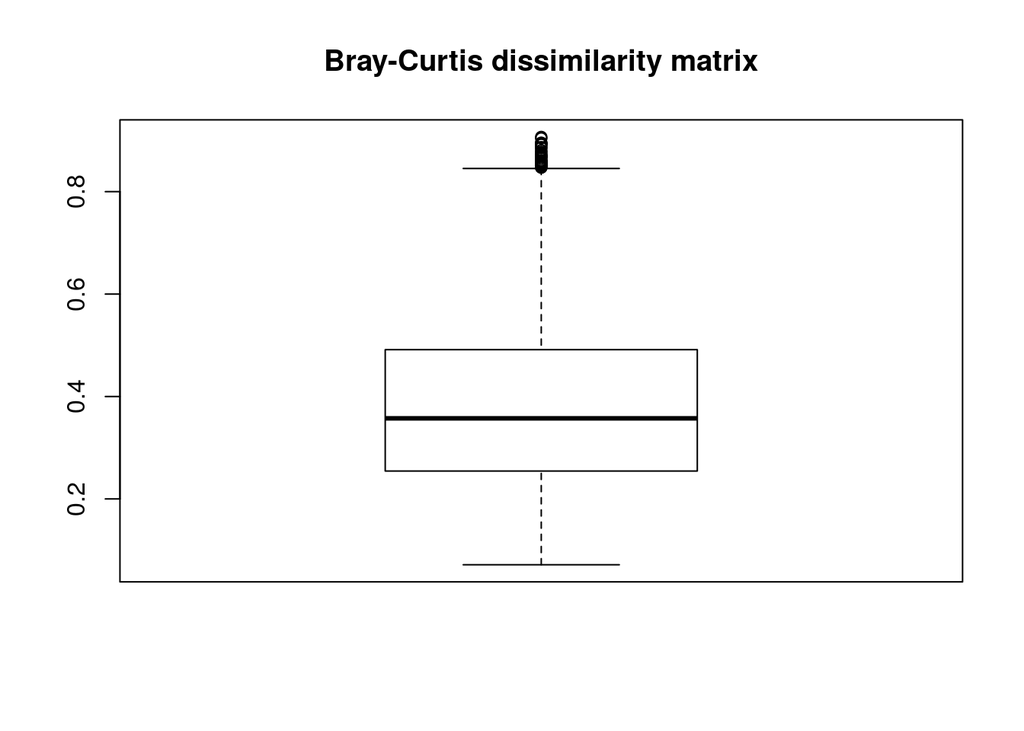

#### 2.3.6.2) Hierarchical clustering

The only relatively evident cluster we can distinguish in the dendogram stands out in the very left side of the plot.

(To be done: assign Longhurst provinces information to each station and check if any of the central clusters is meaningful regarding to the samples’ geographical ubication)

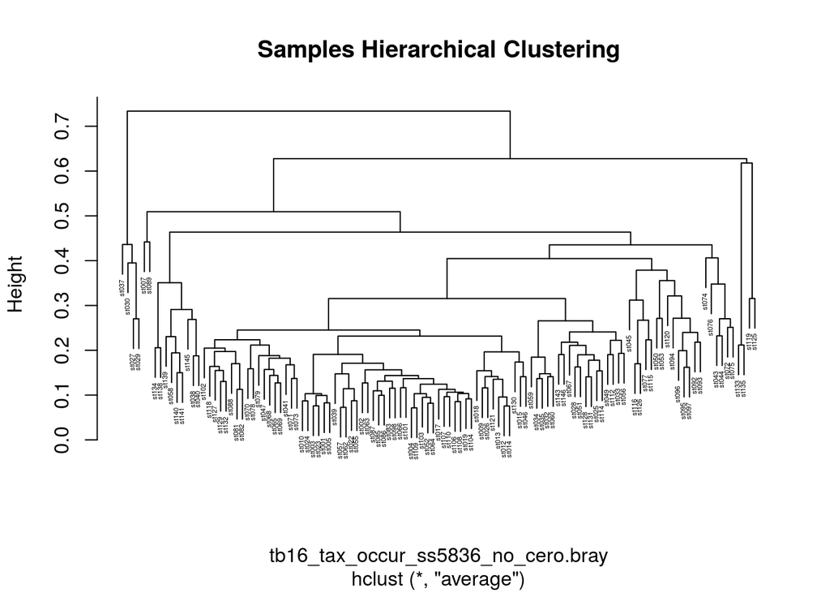

#### 2.3.6.3) Non-metric multidimensional scaling

```
##
## Call:
## monoMDS(dist = tb16_tax_occur_ss5836_no_cero.bray)
##
## Non-metric Multidimensional Scaling
##
## 117 points, dissimilarity 'bray', call 'vegdist(x = tb16_tax_occur_ss5836_no_cero, method = "bray")'
##
## Dimensions: 2
## Stress:     0.1330533
## Stress type 1, weak ties
## Scores scaled to unit root mean square, rotated to principal components
## Stopped after 118 iterations: Stress nearly unchanged (ratio > sratmax)
```

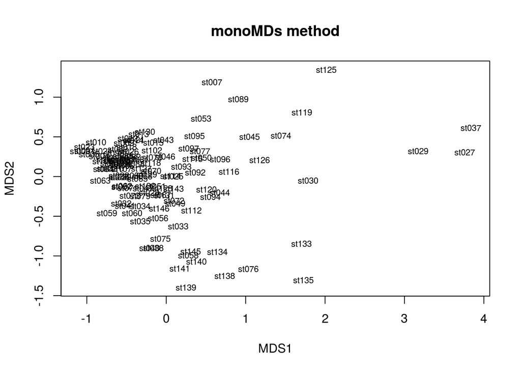

When implementing a most robut function for computing NMDS plots, the result is quiet the same:

```
## ... procrustes: rmse 0.006778966  max resid 0.05528081
## ... procrustes: rmse 0.0009401818  max resid 0.007321792
## *** Solution reached
```

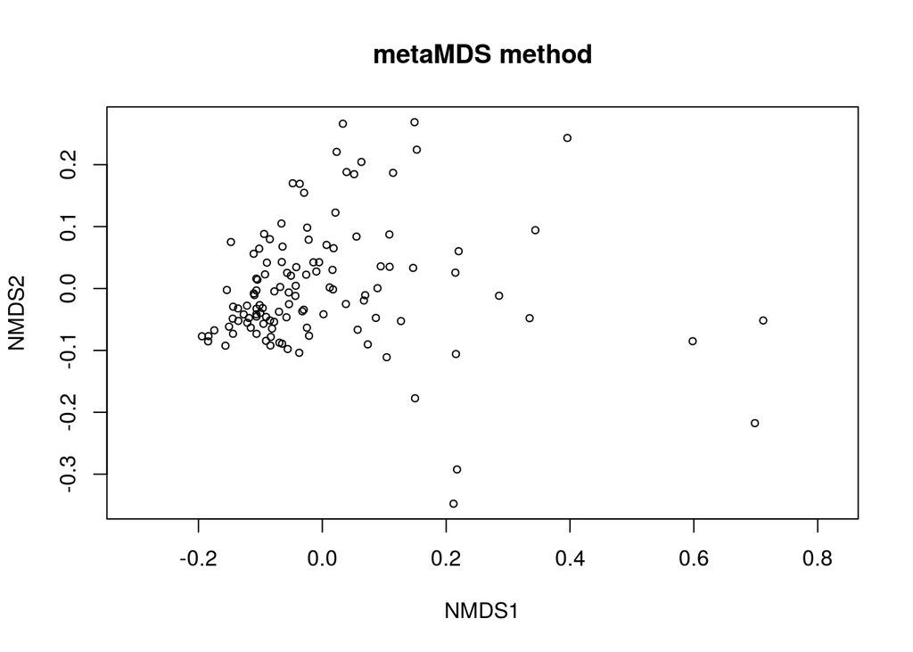

## 2.4) Geographical analysis

Working datasets:

1. Community matrix: tb16_tax_occur_ss5836_no_cero

```r
dim(tb16_tax_occur_ss5836_no_cero)
```

```
## [1] 117 921
```

```r
tb16_tax_occur_ss5836_no_cero[1:5, 1:5]
```

```
##       OTU_1 OTU_2 OTU_3 OTU_4 OTU_5
## st001  4063   680     0    91    90
## st002  3473   954     1   214    87
## st003  4334   688     0    86    53
## st004  3881   706     3   155    84
## st005  4139   773     0   140   118
```

2. Community Bray-Curtis: tb16_tax_occur_ss5836_no_cero.bray

```r
tb16_tax_occur_ss5836_no_cero.bray<-as.matrix(tb16_tax_occur_ss5836_no_cero.bray)
```

3. Stations distances in km: geo_distances_MP_16S

```r
dim(geo_distances_MP_16S)
```

```
## [1] 117 117
```

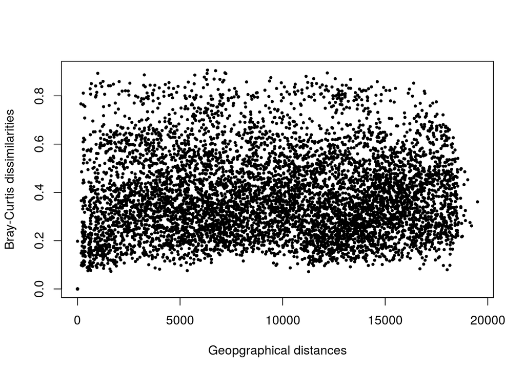

```r
plot(geo_distances_MP_16S, tb16_tax_occur_ss5836_no_cero.bray, pch=19, cex=0.4, xlab="Geopgraphical distances", ylab="Bray-Curtis dissimilarities")
```

### 2.4.1) Mantel correlograms

Mantel statistic is -significantlly- so low, meaning that the correlation between samples dissimilarity and geographical distances is weak.

```r
mantel(geo_distances_MP_16S, tb16_tax_occur_ss5836_no_cero.bray)
```

```
##
## Mantel statistic based on Pearson's product-moment correlation
##
## Call:
## mantel(xdis = geo_distances_MP_16S, ydis = tb16_tax_occur_ss5836_no_cero.bray)
##
## Mantel statistic r: 0.01288
##       Significance: 0.199
##
## Upper quantiles of permutations (null model):
##    90%    95%  97.5%    99%
## 0.0230 0.0303 0.0395 0.0543
## Permutation: free
## Number of permutations: 999
```

Maximum distance between samples:

```
## [1] 19500.19
```

Minimum distance between samples:

```
## [1] 0
```

Correlograms:

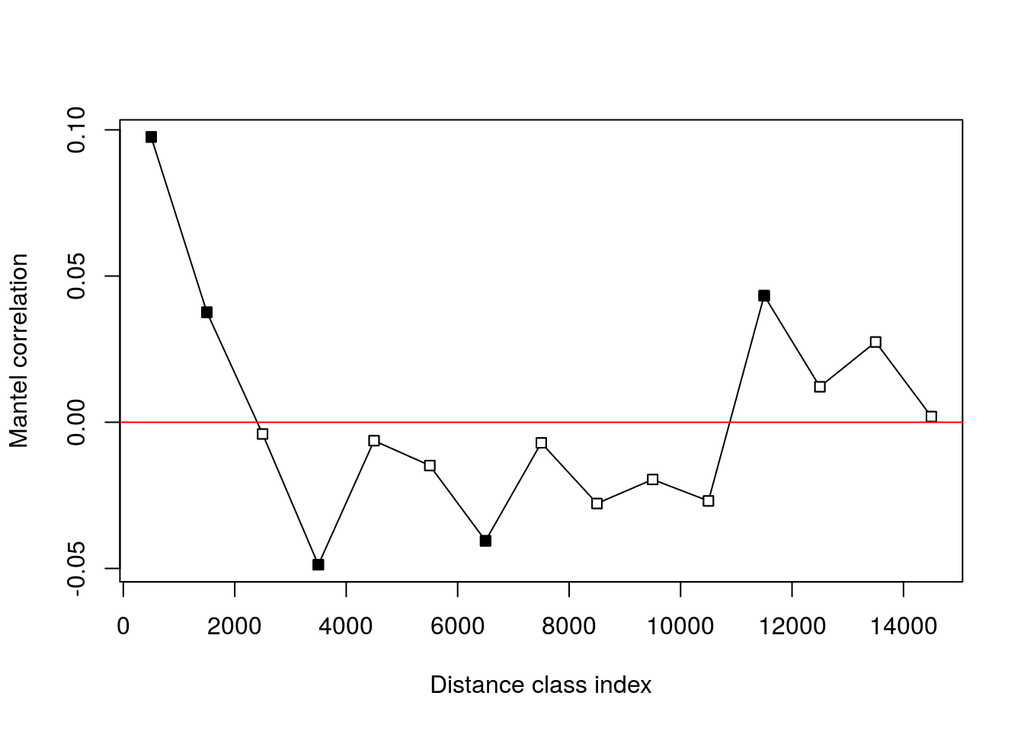

```r
MP_16s_ss5836_mantel_correl_by_1000km<-mantel.correlog(tb16_tax_occur_ss5836_no_cero.bray, D.geo=geo_distances_MP_16S, break.pts=seq(0,20000, by=1000))
plot(MP_16s_ss5836_mantel_correl_by_1000km)
```

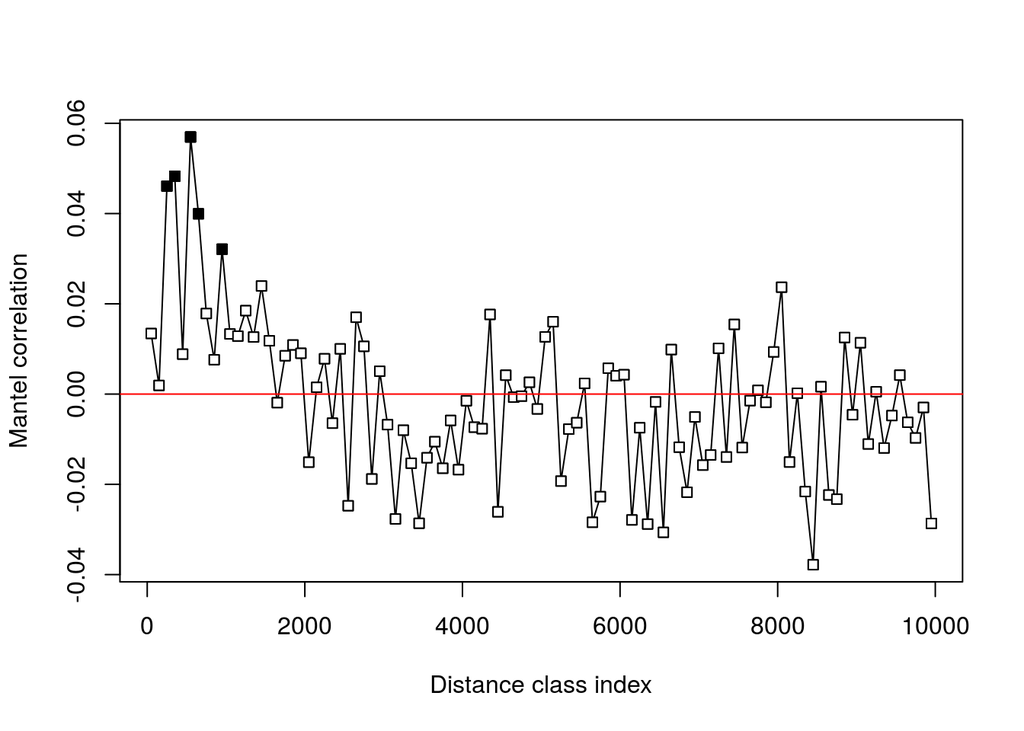

```r
MP_16s_ss5836_mantel_correl_by_100km<-mantel.correlog(tb16_tax_occur_ss5836_no_cero.bray, D.geo=geo_distances_MP_16S, break.pts=seq(0,20000, by=100))
plot(MP_16s_ss5836_mantel_correl_by_100km)
```

```r
mantel(tb18_tax_occur_ss8522_no_cero.bray, tb16_tax_occur_ss5836_no_cero.bray)
```

```
##
## Mantel statistic based on Pearson's product-moment correlation
##
## Call:
## mantel(xdis = tb18_tax_occur_ss8522_no_cero.bray, ydis = tb16_tax_occur_ss5836_no_cero.bray)
##
## Mantel statistic r: 0.6253
##       Significance: 0.001
##
## Upper quantiles of permutations (null model):
##    90%    95%  97.5%    99%
## 0.0808 0.1084 0.1300 0.1689
## Permutation: free
## Number of permutations: 999
```

## 2.5) Abundance vs. occurence

In the following plot, we can appreciate the OTUs distribution according to their percentage of occurence and relative abundance. The red line keeps up OTUs that occur in more than 80% of the samples, the green line limits regionally rare OTUs (< 0.001%), and the blue one restricts regionally abundant OTUs (> 0.1%).

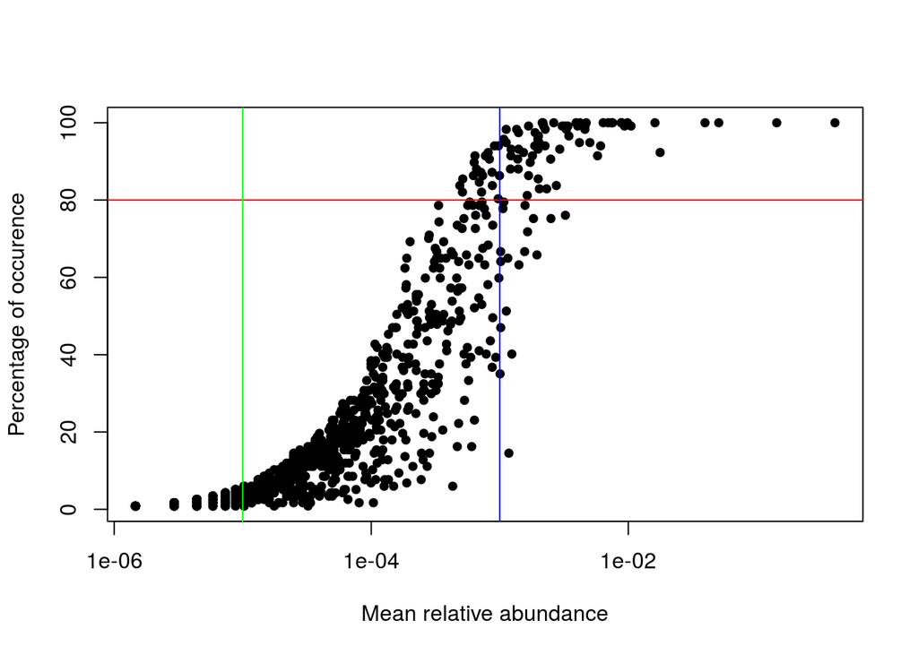

Regionally abundant OTUs (relative abundance over 0.1%):

```
##         mean_rabund perc_occur
## OTU_1   0.405690000  100.00000
## OTU_2   0.142979327  100.00000
## OTU_4   0.050603973  100.00000
## OTU_5   0.039540899  100.00000
## OTU_3   0.017698869   92.30769
## OTU_6   0.016137678  100.00000
## OTU_552 0.010508017   99.14530
## OTU_10  0.009866552  100.00000
## OTU_23  0.009348108   99.14530
## OTU_435 0.008879457  100.00000
## OTU_104 0.008807695  100.00000
## OTU_12  0.007561379  100.00000
## OTU_9   0.007381241  100.00000
## OTU_13  0.006978495  100.00000
## OTU_28  0.006380966  100.00000
## OTU_20  0.006092453   94.01709
## OTU_7   0.005767327   91.45299
## OTU_34  0.005027738   94.87179
## OTU_198 0.004707006  100.00000
## OTU_11  0.004608882   99.14530
## OTU_8   0.004598630   98.29060
## OTU_19  0.004204671  100.00000
## OTU_368 0.004172452   94.87179
## OTU_234 0.004042108   99.14530
## OTU_25  0.003926410  100.00000
## OTU_33  0.003450437   96.58120
## OTU_14  0.003391856   99.14530
## OTU_37  0.003296661   98.29060
## OTU_40  0.003242474   76.06838
## OTU_21  0.003226364   99.14530
## OTU_29  0.003060872   99.14530
## OTU_15  0.002930528   93.16239
## OTU_24  0.002756249   83.76068
## OTU_45  0.002631764  100.00000
## OTU_16  0.002501421   75.21368
## OTU_709 0.002489704   90.59829
## OTU_27  0.002316890   82.90598
## OTU_102 0.002255379   98.29060
## OTU_36  0.002250986   94.01709
```

[output cut: 29 more lines]

```
## OTU_93  0.001225813   93.16239
## OTU_84  0.001221420   91.45299
## OTU_98  0.001211168   88.03419
## OTU_61  0.001177484   14.52991
## OTU_46  0.001155516   64.95726
## OTU_52  0.001124761   51.28205
## OTU_404 0.001121831   98.29060
## OTU_89  0.001121831   94.87179
## OTU_48  0.001076431   79.48718
## OTU_147 0.001074966   95.72650
## OTU_103 0.001058857   77.77778
## OTU_74  0.001017850   64.10256
## OTU_67  0.001017850   47.00855
## OTU_66  0.001016385   66.66667
## OTU_59  0.001006133   35.04274
```

```r
dim(tb16_ss5836_abundant_sorted)
```

```
## [1] 83  2
```

Proportion of regionally abundant OTUs (%):

```
## [1] 0.6430868
```

Cosmopolitan OTUs (relative abundance over 0.1% and occurence in more than 80% of samples):

```
##         mean_rabund perc_occur
## OTU_1   0.405690000  100.00000
## OTU_2   0.142979327  100.00000
## OTU_4   0.050603973  100.00000
## OTU_5   0.039540899  100.00000
## OTU_6   0.016137678  100.00000
## OTU_10  0.009866552  100.00000
## OTU_435 0.008879457  100.00000
## OTU_104 0.008807695  100.00000
## OTU_12  0.007561379  100.00000
## OTU_9   0.007381241  100.00000
## OTU_13  0.006978495  100.00000
## OTU_28  0.006380966  100.00000
## OTU_198 0.004707006  100.00000
## OTU_19  0.004204671  100.00000
## OTU_25  0.003926410  100.00000
## OTU_45  0.002631764  100.00000
## OTU_70  0.002168972  100.00000
## OTU_724 0.002139681  100.00000
## OTU_552 0.010508017   99.14530
## OTU_23  0.009348108   99.14530
## OTU_11  0.004608882   99.14530
## OTU_234 0.004042108   99.14530
## OTU_14  0.003391856   99.14530
## OTU_21  0.003226364   99.14530
## OTU_29  0.003060872   99.14530
## OTU_39  0.002195333   99.14530
## OTU_90  0.001675425   99.14530
## OTU_8   0.004598630   98.29060
## OTU_37  0.003296661   98.29060
## OTU_102 0.002255379   98.29060
## OTU_42  0.001353228   98.29060
## OTU_404 0.001121831   98.29060
## OTU_163 0.001884853   97.43590
## OTU_247 0.001400093   97.43590
## OTU_33  0.003450437   96.58120
## OTU_166 0.001999086   96.58120
## OTU_18  0.001980047   95.72650
## OTU_147 0.001074966   95.72650
## OTU_34  0.005027738   94.87179
```

[output cut: 11 more lines]

```
## OTU_41  0.001530436   92.30769
## OTU_7   0.005767327   91.45299
## OTU_694 0.001796981   91.45299
## OTU_84  0.001221420   91.45299
## OTU_709 0.002489704   90.59829
## OTU_62  0.001378125   90.59829
## OTU_55  0.001725219   89.74359
## OTU_56  0.001392770   88.03419
## OTU_98  0.001211168   88.03419
## OTU_177 0.001675425   86.32479
## OTU_35  0.001990299   85.47009
## OTU_24  0.002756249   83.76068
## OTU_27  0.002316890   82.90598
## OTU_240 0.002034235   82.90598
## OTU_32  0.001635882   81.19658
```

```r
dim(otu_tb16_ss5836_cosmop_sorted)
```

```
## [1] 65  2
```

Proportion of cosmopolitan OTUs (%):

```
## [1] 0.254059
```

Number and proportion (%) of rare OTUs:

```r
dim(otu_tb16_ss5836_rabund_percoccur[otu_tb16_ss5836_rabund_percoccur$mean_rabund < 0.00001 & otu_tb16_ss5836_rabund_percoccur$mean_rabund >0,])
```

```
## [1] 217   2
```

```
## [1] 65.70204
```

## 2.6) Taxonomic composition analysis

### 2.6.1) Normalized data

#### 2.6.1.1) Absolute values

Let’s add the taxonomic classification to the left OTUs by merging “tb16_tax_occur_ss5836_no_cero” with “tb16_tax”.

```
## [1] 921 124
```

```
##   Row.names st001 st002 st003 st004
## 1     OTU_1  4063  3473  4334  3881
## 2    OTU_10    16    36    14    21
## 3   OTU_100     0     0     0     0
## 4  OTU_1001     0     0     0     0
## 5  OTU_1004     0     0     0     0
```

```
## [1] 921 123
```

```
##          st001 st002 st003 st004 st005
## OTU_1     4063  3473  4334  3881  4139
## OTU_10      16    36    14    21    11
## OTU_100      0     0     0     0     0
## OTU_1001     0     0     0     0     0
## OTU_1004     0     0     0     0     0
```

```
## [1] 921 124
```

```
##                      class_A                class_B OTU_no
## OTU_1          Cyanobacteria        Prochlorococcus      1
## OTU_2 heterotrophic_bacteria heterotrophic_bacteria      2
## OTU_3 heterotrophic_bacteria heterotrophic_bacteria      3
## OTU_4 heterotrophic_bacteria heterotrophic_bacteria      4
## OTU_5          Cyanobacteria          Synechococcus      5
```

```
## [1]  87 124
```

```
## [1] 834 124
```

```
##         st146
## OTU_54      3
## OTU_57     17
## OTU_58      1
## OTU_80      0
## OTU_114     0
##                                                                SILVA_taxonomic_classification
## OTU_54                EU237456.1.1310_Bacteria;Cyanobacteria;Chloroplast;uncultured_bacterium
## OTU_57   AY664138.1.1204_Bacteria;Cyanobacteria;Chloroplast;uncultured_phototrophic_eukaryote
## OTU_58                                                                                   <NA>
## OTU_80  HM565911.2962.4423_Bacteria;Cyanobacteria;Chloroplast;uncultured_prymnesiophyte_C8704
## OTU_114               JN986350.1.1460_Bacteria;Cyanobacteria;Chloroplast;uncultured_bacterium
##                                                                                                                                                              Phytoref_taxonomic_classification
## OTU_54  5523_AB847984|Eukaryota|Hacrobia|Haptophyta|Prymnesiophyceae|Prymnesiophyceae_X|Prymnesiophyceae_XX|Prymnesiophyceae_XXX|Braarudosphaeraceae|Braarudosphaera|Braarudosphaera_bigelowii
## OTU_57            474_Eukaryota|Stramenopiles|Ochrophyta|Dictyochophyceae|Dictyochophyceae_X|Dictyochophyceae_XX|Dictyochophyceae_XXX|Dictyochophyceae_XXXX|Helicopedinella|Helicopedinella_sp
## OTU_58       432_DQ438491|Eukaryota|Archaeplastida|Chlorophyta|Prasinophyceae|Prasinophyceae_X|Prasino-clade-9|Prasino-clade-9_X|Prasino-clade-9_XX|Prasino-clade-9_XXX|Prasino-clade-9_XXX_sp
## OTU_80                                                                                                                                                                                    <NA>
## OTU_114   891_FJ649309|Eukaryota|Archaeplastida|Chlorophyta|Prasinophyceae|Prasinophyceae_X|Prasino-clade-7|Prasino-clade-7_X|Prasino-clade-7_X-B|Prasino-clade-7_X-B1|Prasino-clade-7_X-B1_sp
##         SILVA_funct_classif Phytoref_funct_classif          class_A
## OTU_54              plastid                plastid Prymnesiophyceae
## OTU_57              plastid                plastid Dictyochophyceae
## OTU_58                 <NA>                plastid   Prasinophyceae
## OTU_80              plastid                   <NA>   other_plastids
## OTU_114             plastid                plastid   Prasinophyceae
##                  class_B OTU_no
## OTU_54  Prymnesiophyceae     54
## OTU_57  Dictyochophyceae     57
## OTU_58    Prasinophyceae     58
## OTU_80    other_plastids     80
## OTU_114   Prasinophyceae    114
```

```
##       st146
## OTU_1  1990
## OTU_2   960
## OTU_3    79
## OTU_4   155
## OTU_5   163
##                                                                                                        SILVA_taxonomic_classification
## OTU_1   KC002097.1.1314_Bacteria;Cyanobacteria;Cyanobacteria;SubsectionI;FamilyI;Prochlorococcus;unidentified_marine_bacterioplankton
## OTU_2                          EU800388.1.1465_Bacteria;Proteobacteria;Alphaproteobacteria;SAR11_clade;Surface_1;uncultured_bacterium
## OTU_3 KJ590614.1.1421_Bacteria;Proteobacteria;Alphaproteobacteria;Rhodobacterales;Rhodobacteraceae;Sulfitobacter;uncultured_bacterium
## OTU_4  EU805005.1.1343_Bacteria;Actinobacteria;Acidimicrobiia;Acidimicrobiales;OM1_clade;Candidatus_Actinomarina;uncultured_bacterium
## OTU_5     KC000519.1.1314_Bacteria;Cyanobacteria;Cyanobacteria;SubsectionI;FamilyI;Synechococcus;unidentified_marine_bacterioplankton
##                                                                                                Phytoref_taxonomic_classification
## OTU_1   EU803052.1.1425|Bacteria|Cyanobacteria|Cyanobacteria|SubsectionI|FamilyI|Prochlorococcus|uncultured|uncultured+bacterium
## OTU_2                                                                                                                       <NA>
## OTU_3                                                                                                                       <NA>
## OTU_4                                                                                                                       <NA>
## OTU_5 AY663935.1.1244|Bacteria|Cyanobacteria|Cyanobacteria|SubsectionI|FamilyI|Synechococcus|uncultured|uncultured+Synechococcus
##       SILVA_funct_classif Phytoref_funct_classif                class_A
## OTU_1              cyanob                 cyanob          Cyanobacteria
## OTU_2            bacteria                   <NA> heterotrophic_bacteria
## OTU_3            bacteria                   <NA> heterotrophic_bacteria
## OTU_4            bacteria                   <NA> heterotrophic_bacteria
## OTU_5              cyanob                 cyanob          Cyanobacteria
##                      class_B OTU_no
## OTU_1        Prochlorococcus      1
## OTU_2 heterotrophic_bacteria      2
## OTU_3 heterotrophic_bacteria      3
## OTU_4 heterotrophic_bacteria      4
## OTU_5          Synechococcus      5
```

```r
class_summary_reads_per_class_16S_protists<-aggregate(rowSums(tb16_protists[1:117]), list(tb16_protists$class_A), sum)
# count the different groups

class_summary_otus_per_class_16S_protists<-aggregate(rowSums(tb16_protists[1:117]), list(tb16_protists$class_A), length)

## READS PER CLASS ##
attach(class_summary_reads_per_class_16S_protists)
class_summary_reads_per_class_16S_protists_order<-class_summary_reads_per_class_16S_protists[order(-x),]
detach(class_summary_reads_per_class_16S_protists)
class_summary_reads_per_class_16S_protists_order
```

```
##               Group.1    x
## 10   Prymnesiophyceae 4335
## 7      other_plastids 2149
## 5    Dictyochophyceae 1056
## 9      Prasinophyceae  906
## 6     Mamiellophyceae  358
## 8       Pelagophyceae   69
## 1     Bacillariophyta   49
## 2       Bolidophyceae   35
## 4     Cryptomonadales   26
## 11         Rappemonad   26
## 3  Chlorarachniophyta    3
```

```r
#fix column names
row.names(class_summary_reads_per_class_16S_protists_order)<-class_summary_reads_per_class_16S_protists_order[,1]
class_summary_reads_per_class_16S_protists_order<-class_summary_reads_per_class_16S_protists_order[c(-1)]
colnames(class_summary_reads_per_class_16S_protists_order)<-c("reads_per_class")


## OTUs PER CLASS ##
attach(class_summary_otus_per_class_16S_protists)
class_summary_otus_per_class_16S_protists_order<-class_summary_otus_per_class_16S_protists[order(-x),]
detach(class_summary_otus_per_class_16S_protists)
class_summary_otus_per_class_16S_protists_order
```

```
##               Group.1  x
## 7      other_plastids 31
## 10   Prymnesiophyceae 27
## 9      Prasinophyceae 10
## 5    Dictyochophyceae  7
## 6     Mamiellophyceae  4
## 1     Bacillariophyta  3
## 2       Bolidophyceae  1
## 3  Chlorarachniophyta  1
## 4     Cryptomonadales  1
## 8       Pelagophyceae  1
## 11         Rappemonad  1
```

```r
row.names(class_summary_otus_per_class_16S_protists_order)<-class_summary_otus_per_class_16S_protists_order[,1]
class_summary_otus_per_class_16S_protists_order<-class_summary_otus_per_class_16S_protists_order[c(-1)]
colnames(class_summary_otus_per_class_16S_protists_order)<-c("OTUs_per_class")
```

```r
class_summary_reads_per_class_16S_bacteria<-aggregate(rowSums(tb16_bacteria[1:117]), list(tb16_bacteria$class_A), sum)
# count the different groups

class_summary_otus_per_class_16S_bacteria<-aggregate(rowSums(tb16_bacteria[1:117]), list(tb16_bacteria$class_A), length)

## READS PER CLASS ##
attach(class_summary_reads_per_class_16S_bacteria)
class_summary_reads_per_class_16S_bacteria_order<-class_summary_reads_per_class_16S_bacteria[order(-x),]
detach(class_summary_reads_per_class_16S_bacteria)
class_summary_reads_per_class_16S_bacteria_order
```

```
##                  Group.1      x
## 2 heterotrophic_bacteria 349867
## 1          Cyanobacteria 323933
```

```r
#fix column names
row.names(class_summary_reads_per_class_16S_bacteria_order)<-class_summary_reads_per_class_16S_bacteria_order[,1]
class_summary_reads_per_class_16S_bacteria_order<-class_summary_reads_per_class_16S_bacteria_order[c(-1)]
colnames(class_summary_reads_per_class_16S_bacteria_order)<-c("reads_per_class")


## OTUs PER CLASS ##
attach(class_summary_otus_per_class_16S_bacteria)
class_summary_otus_per_class_16S_bacteria_order<-class_summary_otus_per_class_16S_bacteria[order(-x),]
detach(class_summary_otus_per_class_16S_bacteria)
class_summary_otus_per_class_16S_bacteria_order
```

```
##                  Group.1   x
## 2 heterotrophic_bacteria 805
## 1          Cyanobacteria  29
```

```r
row.names(class_summary_otus_per_class_16S_bacteria_order)<-class_summary_otus_per_class_16S_bacteria_order[,1]
class_summary_otus_per_class_16S_bacteria_order<-class_summary_otus_per_class_16S_bacteria_order[c(-1)]
colnames(class_summary_otus_per_class_16S_bacteria_order)<-c("OTUs_per_class")
```

```
##         st001 st002 st003 st004 st005
## OTU_80      7     5     0     1     5
## OTU_146     0     3     1     1     3
## OTU_170     0     2     2     3     1
## OTU_182     0     1     0     2     0
## OTU_213     0     0     0     0     0
```

```
##         st001 st002 st003 st004 st005
## OTU_80      7     5     0     1     5
## OTU_146     0     3     1     1     3
## OTU_170     0     2     2     3     1
## OTU_182     0     1     0     2     0
## OTU_213     0     0     0     0     0
```

```
## [1]  31 117
```

```
## [1] 115
```

```
## [1] 117
```

```
## [1] 96
```

```
## [1] 109
```

```
## [1] 26
```

```
## [1] 26
```

```
## [1] 25
```

```
## [1] 3
```

```
## [1] 14
```

```
## [1] 27
```

```
## [1] 22
```

```
## [1] 117
```

```
## [1] 117
```

```
##                    reads_per_class OTUs_per_class
## Bacillariophyta                 49              3
## Bolidophyceae                   35              1
## Chlorarachniophyta               3              1
## Cryptomonadales                 26              1
## Dictyochophyceae              1056              7
```

```
##                        reads_per_class OTUs_per_class
## Cyanobacteria                   323933             29
## heterotrophic_bacteria          349867            805
## NA                                  NA             NA
## NA.1                                NA             NA
## NA.2                                NA             NA
```

OTUs per class vs. samples in which they occur - PROTISTS [PLOT DESCRIPTION]

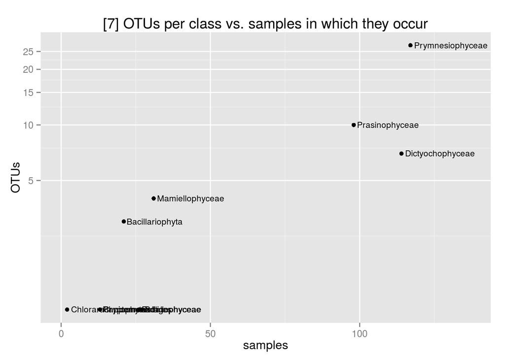

Reads per class vs. OTUs per class - PROTISTS [PLOT DESCRIPTION]

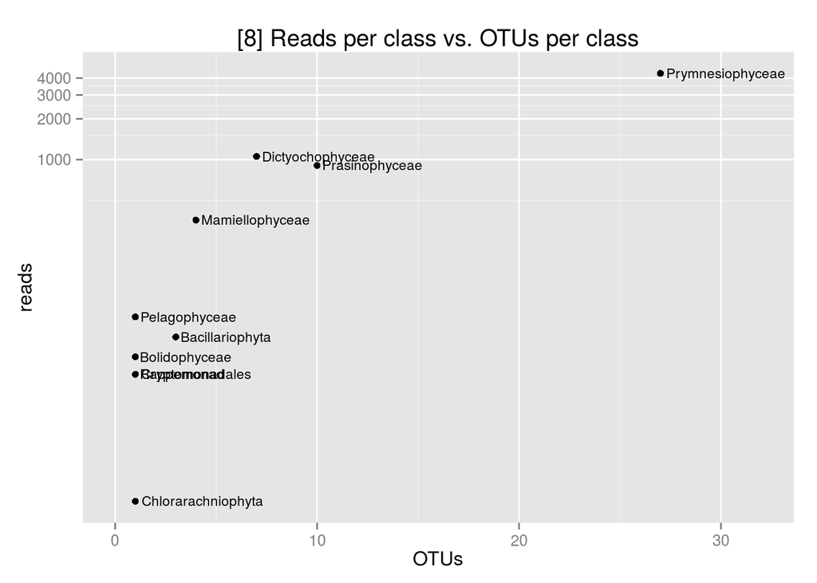

OTUs per class vs. samples in which they occur - PROTISTS vs CYANOBACTERIA [PLOT DESCRIPTION]

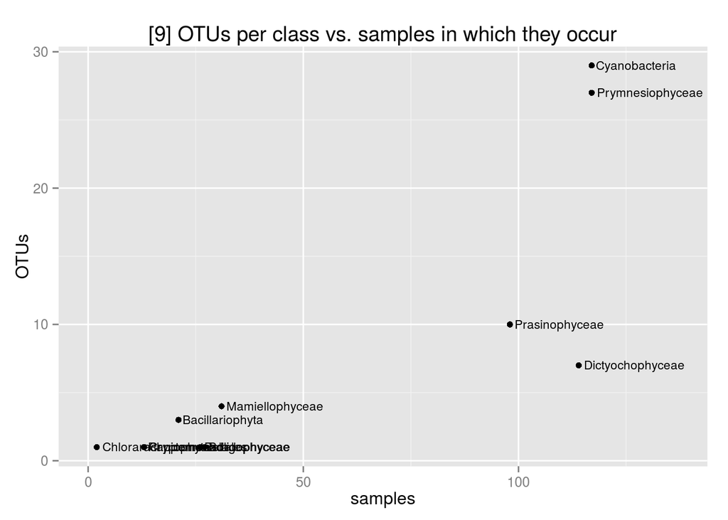

Reads per class vs. OTUs per class - PROTISTS vs CYANOBACTERIA [PLOT DESCRIPTION]

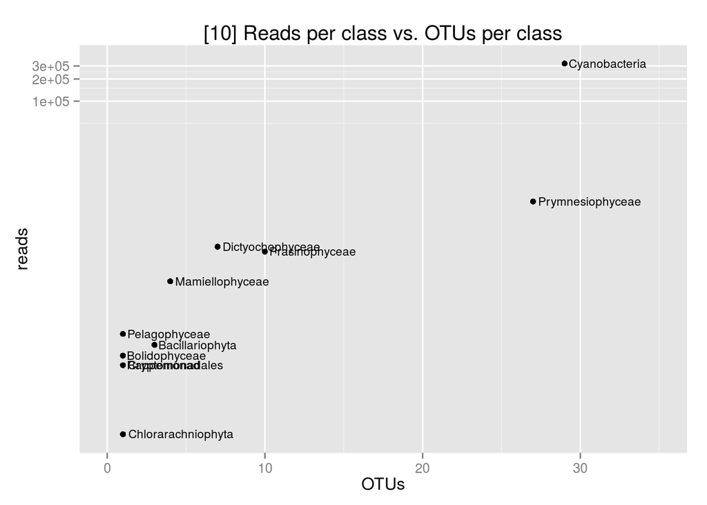

#### 2.6.1.2) Relative values

```
##   reads_per_class    OTUs_per_class samples_per_class
##          100.0000          100.0000          394.8718
```

```
##                    reads_per_class OTUs_per_class samples_per_class
## Prymnesiophyceae       63.16479674      48.214286        100.000000
## Dictyochophyceae       15.38685706      12.500000         97.435897
## Prasinophyceae         13.20122395      17.857143         83.760684
## Mamiellophyceae         5.21637768       7.142857         26.495726
## Pelagophyceae           1.00539123       1.785714         22.222222
## Bacillariophyta         0.71397348       5.357143         17.948718
## Bolidophyceae           0.50998106       1.785714         23.076923
## Cryptomonadales         0.37884307       1.785714         11.111111
## Rappemonad              0.37884307       1.785714         11.111111
## Chlorarachniophyta      0.04371266       1.785714          1.709402
```

OTUs per class vs. samples in which they occur - PROTISTS [PLOT DESCRIPTION]

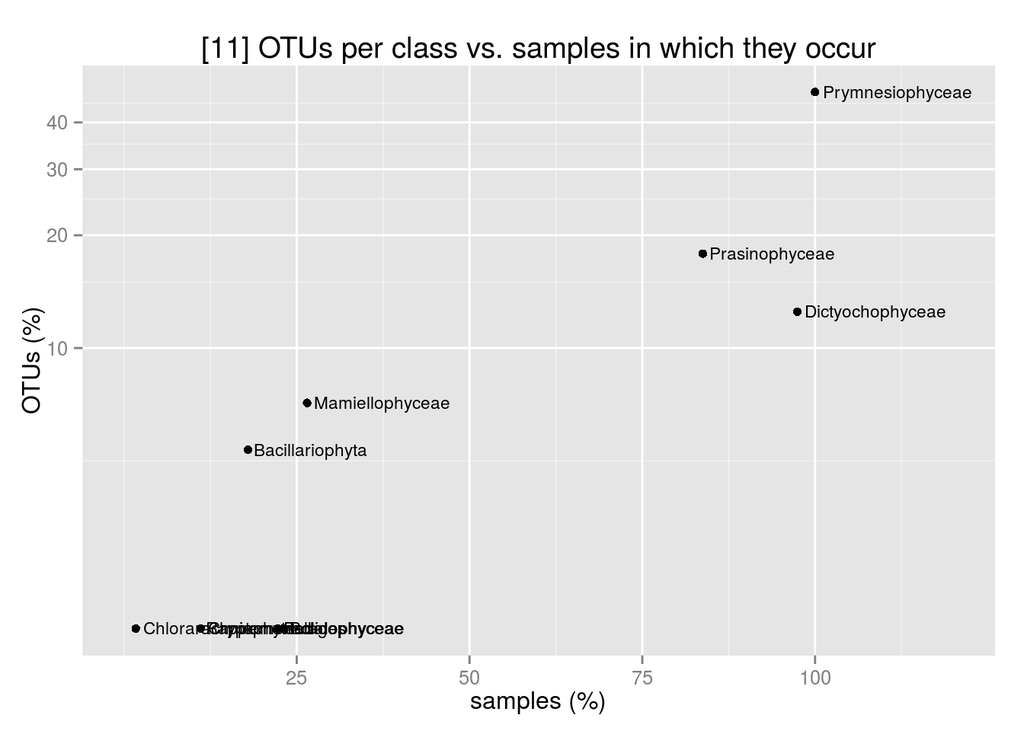

Reads per class vs. OTUs per class - PROTISTS [PLOT DESCRIPTION]

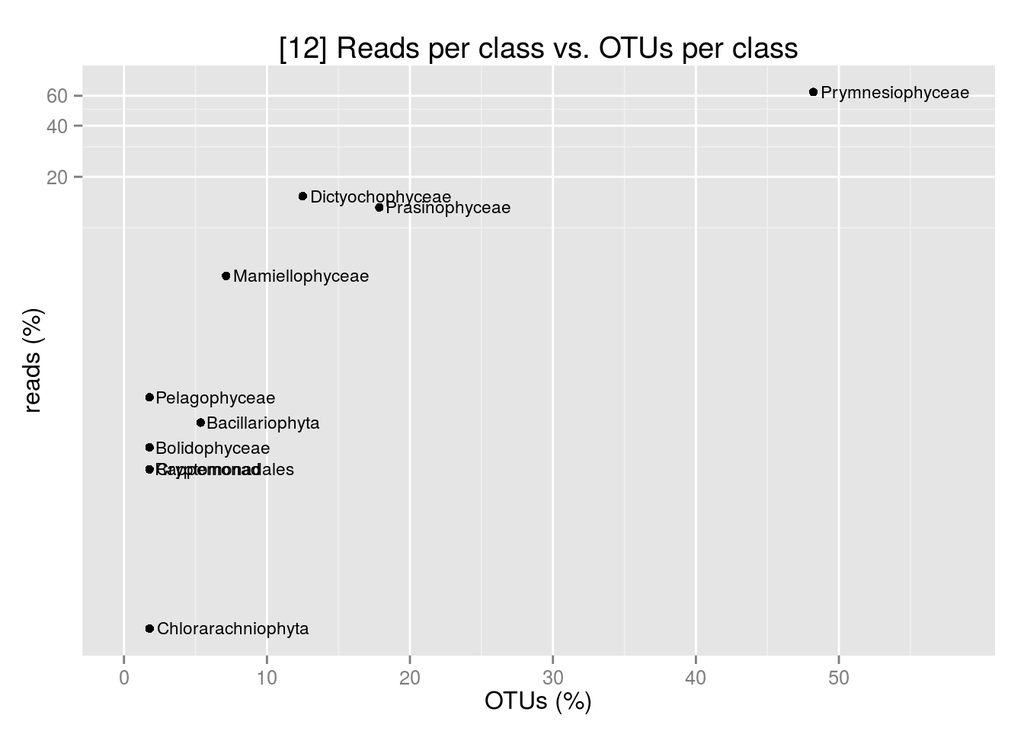

OTUs per class vs. samples in which they occur - PROTISTS vs. CYANOBACTERIA [PLOT DESCRIPTION]

```
##   reads_per_class    OTUs_per_class samples_per_class
##          100.0000          100.0000          494.8718
```

```
##                    reads_per_class OTUs_per_class samples_per_class
## Prymnesiophyceae      1.310475e+00      31.764706        100.000000
## Dictyochophyceae      3.192300e-01       8.235294         97.435897
## Prasinophyceae        2.738848e-01      11.764706         83.760684
## Mamiellophyceae       1.082238e-01       4.705882         26.495726
## Pelagophyceae         2.085878e-02       1.176471         22.222222
## Bacillariophyta       1.481275e-02       3.529412         17.948718
## Bolidophyceae         1.058054e-02       1.176471         23.076923
## Cryptomonadales       7.859829e-03       1.176471         11.111111
## Rappemonad            7.859829e-03       1.176471         11.111111
## Chlorarachniophyta    9.069033e-04       1.176471          1.709402
## Cyanobacteria         9.792531e+01      34.117647        100.000000
```

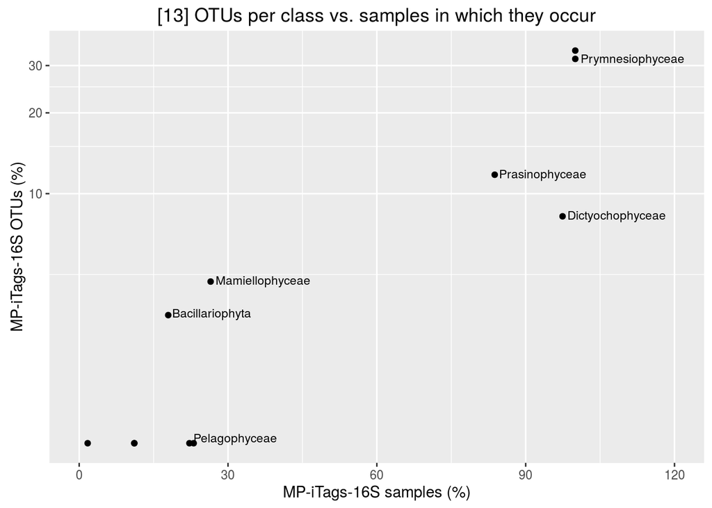

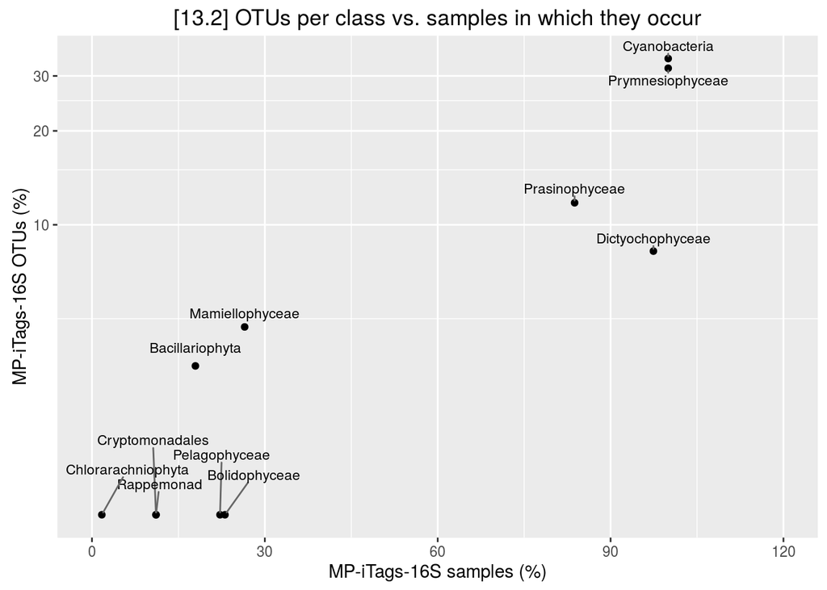

Reads per class vs. OTUs per class - PROTISTS vs CYANOBACTERIA [PLOT DESCRIPTION]

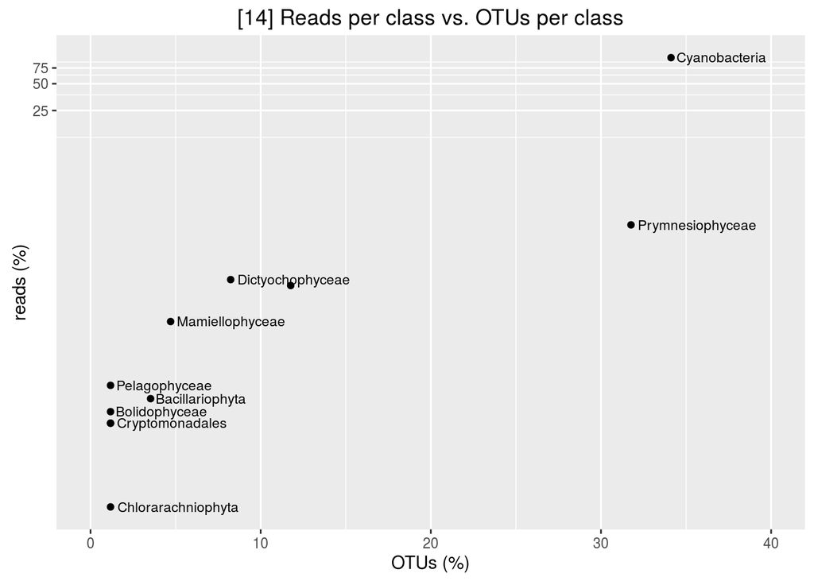

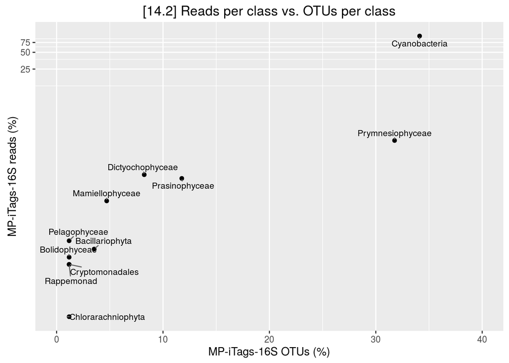

### 2.6.2) Non-normalized data

```
## [1] 960 124
```

```
##   Row.names st001 st002 st003 st004
## 1     OTU_1 72073 45381 40792 26317
## 2    OTU_10   317   449   135   164
## 3   OTU_100     0     0     0     0
## 4  OTU_1001     0     0     0     0
## 5  OTU_1002     0     0     0     0
```

```
## [1] 960 123
```

```
##          st001 st002 st003 st004 st005
## OTU_1    72073 45381 40792 26317 65068
## OTU_10     317   449   135   164   170
## OTU_100      0     0     0     0     0
## OTU_1001     0     0     0     0     0
## OTU_1002     0     0     0     0     0
```

```
## [1] 960 124
```

```
##                      class_A                class_B OTU_no
## OTU_1          Cyanobacteria        Prochlorococcus      1
## OTU_2 heterotrophic_bacteria heterotrophic_bacteria      2
## OTU_3 heterotrophic_bacteria heterotrophic_bacteria      3
## OTU_4 heterotrophic_bacteria heterotrophic_bacteria      4
## OTU_5          Cyanobacteria          Synechococcus      5
```

```
## [1]  87 124
```

```
## [1] 873 124
```

```
##         st146
## OTU_54      4
## OTU_57     26
## OTU_58      1
## OTU_80      0
## OTU_114     0
##                                                                SILVA_taxonomic_classification
## OTU_54                EU237456.1.1310_Bacteria;Cyanobacteria;Chloroplast;uncultured_bacterium
## OTU_57   AY664138.1.1204_Bacteria;Cyanobacteria;Chloroplast;uncultured_phototrophic_eukaryote
## OTU_58                                                                                   <NA>
## OTU_80  HM565911.2962.4423_Bacteria;Cyanobacteria;Chloroplast;uncultured_prymnesiophyte_C8704
## OTU_114               JN986350.1.1460_Bacteria;Cyanobacteria;Chloroplast;uncultured_bacterium
##                                                                                                                                                              Phytoref_taxonomic_classification
## OTU_54  5523_AB847984|Eukaryota|Hacrobia|Haptophyta|Prymnesiophyceae|Prymnesiophyceae_X|Prymnesiophyceae_XX|Prymnesiophyceae_XXX|Braarudosphaeraceae|Braarudosphaera|Braarudosphaera_bigelowii
## OTU_57            474_Eukaryota|Stramenopiles|Ochrophyta|Dictyochophyceae|Dictyochophyceae_X|Dictyochophyceae_XX|Dictyochophyceae_XXX|Dictyochophyceae_XXXX|Helicopedinella|Helicopedinella_sp
## OTU_58       432_DQ438491|Eukaryota|Archaeplastida|Chlorophyta|Prasinophyceae|Prasinophyceae_X|Prasino-clade-9|Prasino-clade-9_X|Prasino-clade-9_XX|Prasino-clade-9_XXX|Prasino-clade-9_XXX_sp
## OTU_80                                                                                                                                                                                    <NA>
## OTU_114   891_FJ649309|Eukaryota|Archaeplastida|Chlorophyta|Prasinophyceae|Prasinophyceae_X|Prasino-clade-7|Prasino-clade-7_X|Prasino-clade-7_X-B|Prasino-clade-7_X-B1|Prasino-clade-7_X-B1_sp
##         SILVA_funct_classif Phytoref_funct_classif          class_A
## OTU_54              plastid                plastid Prymnesiophyceae
## OTU_57              plastid                plastid Dictyochophyceae
## OTU_58                 <NA>                plastid   Prasinophyceae
## OTU_80              plastid                   <NA>   other_plastids
## OTU_114             plastid                plastid   Prasinophyceae
##                  class_B OTU_no
## OTU_54  Prymnesiophyceae     54
## OTU_57  Dictyochophyceae     57
## OTU_58    Prasinophyceae     58
## OTU_80    other_plastids     80
## OTU_114   Prasinophyceae    114
```

```
##       st146
## OTU_1  3284
## OTU_2  1540
## OTU_3   108
## OTU_4   236
## OTU_5   257
##                                                                                                        SILVA_taxonomic_classification
## OTU_1   KC002097.1.1314_Bacteria;Cyanobacteria;Cyanobacteria;SubsectionI;FamilyI;Prochlorococcus;unidentified_marine_bacterioplankton
## OTU_2                          EU800388.1.1465_Bacteria;Proteobacteria;Alphaproteobacteria;SAR11_clade;Surface_1;uncultured_bacterium
## OTU_3 KJ590614.1.1421_Bacteria;Proteobacteria;Alphaproteobacteria;Rhodobacterales;Rhodobacteraceae;Sulfitobacter;uncultured_bacterium
## OTU_4  EU805005.1.1343_Bacteria;Actinobacteria;Acidimicrobiia;Acidimicrobiales;OM1_clade;Candidatus_Actinomarina;uncultured_bacterium
## OTU_5     KC000519.1.1314_Bacteria;Cyanobacteria;Cyanobacteria;SubsectionI;FamilyI;Synechococcus;unidentified_marine_bacterioplankton
##                                                                                                Phytoref_taxonomic_classification
## OTU_1   EU803052.1.1425|Bacteria|Cyanobacteria|Cyanobacteria|SubsectionI|FamilyI|Prochlorococcus|uncultured|uncultured+bacterium
## OTU_2                                                                                                                       <NA>
## OTU_3                                                                                                                       <NA>
## OTU_4                                                                                                                       <NA>
## OTU_5 AY663935.1.1244|Bacteria|Cyanobacteria|Cyanobacteria|SubsectionI|FamilyI|Synechococcus|uncultured|uncultured+Synechococcus
##       SILVA_funct_classif Phytoref_funct_classif                class_A
## OTU_1              cyanob                 cyanob          Cyanobacteria
## OTU_2            bacteria                   <NA> heterotrophic_bacteria
## OTU_3            bacteria                   <NA> heterotrophic_bacteria
## OTU_4            bacteria                   <NA> heterotrophic_bacteria
## OTU_5              cyanob                 cyanob          Cyanobacteria
##                      class_B OTU_no
## OTU_1        Prochlorococcus      1
## OTU_2 heterotrophic_bacteria      2
## OTU_3 heterotrophic_bacteria      3
## OTU_4 heterotrophic_bacteria      4
## OTU_5          Synechococcus      5
```

```r
class_summary_reads_per_class_16S_protists_non.norm<-aggregate(rowSums(tb16_protists_non.norm[1:117]), list(tb16_protists_non.norm$class_A), sum)
# count the different groups

class_summary_otus_per_class_16S_protists_non.norm<-aggregate(rowSums(tb16_protists_non.norm[1:117]), list(tb16_protists_non.norm$class_A), length)

## READS PER CLASS ##
attach(class_summary_reads_per_class_16S_protists_non.norm)
class_summary_reads_per_class_16S_protists_non.norm_order<-class_summary_reads_per_class_16S_protists_non.norm[order(-x),]
detach(class_summary_reads_per_class_16S_protists_non.norm)
class_summary_reads_per_class_16S_protists_non.norm_order
```

```
##               Group.1     x
## 10   Prymnesiophyceae 32950
## 7      other_plastids 16065
## 5    Dictyochophyceae  8988
## 9      Prasinophyceae  6579
## 6     Mamiellophyceae  1432
## 1     Bacillariophyta   509
## 8       Pelagophyceae   493
## 2       Bolidophyceae   267
## 4     Cryptomonadales   147
## 11         Rappemonad   133
## 3  Chlorarachniophyta    34
```

```r
#fix column names
row.names(class_summary_reads_per_class_16S_protists_non.norm_order)<-class_summary_reads_per_class_16S_protists_non.norm_order[,1]
class_summary_reads_per_class_16S_protists_non.norm_order<-class_summary_reads_per_class_16S_protists_non.norm_order[c(-1)]
colnames(class_summary_reads_per_class_16S_protists_non.norm_order)<-c("reads_per_class")


## OTUs PER CLASS ##
attach(class_summary_otus_per_class_16S_protists_non.norm)
class_summary_otus_per_class_16S_protists_non.norm_order<-class_summary_otus_per_class_16S_protists_non.norm[order(-x),]
detach(class_summary_otus_per_class_16S_protists_non.norm)
class_summary_otus_per_class_16S_protists_non.norm_order
```

```
##               Group.1  x
## 7      other_plastids 31
## 10   Prymnesiophyceae 27
## 9      Prasinophyceae 10
## 5    Dictyochophyceae  7
## 6     Mamiellophyceae  4
## 1     Bacillariophyta  3
## 2       Bolidophyceae  1
## 3  Chlorarachniophyta  1
## 4     Cryptomonadales  1
## 8       Pelagophyceae  1
## 11         Rappemonad  1
```

```r
row.names(class_summary_otus_per_class_16S_protists_non.norm_order)<-class_summary_otus_per_class_16S_protists_non.norm_order[,1]
class_summary_otus_per_class_16S_protists_non.norm_order<-class_summary_otus_per_class_16S_protists_non.norm_order[c(-1)]
colnames(class_summary_otus_per_class_16S_protists_non.norm_order)<-c("OTUs_per_class")
```

```r
class_summary_reads_per_class_16S_bacteria_non.norm<-aggregate(rowSums(tb16_bacteria_non.norm[1:117]), list(tb16_bacteria_non.norm$class_A), sum)
# count the different groups

class_summary_otus_per_class_16S_bacteria_non.norm<-aggregate(rowSums(tb16_bacteria_non.norm[1:117]), list(tb16_bacteria_non.norm$class_A), length)

## READS PER CLASS ##
attach(class_summary_reads_per_class_16S_bacteria_non.norm)
class_summary_reads_per_class_16S_bacteria_non.norm_order<-class_summary_reads_per_class_16S_bacteria_non.norm[order(-x),]
detach(class_summary_reads_per_class_16S_bacteria_non.norm)
class_summary_reads_per_class_16S_bacteria_non.norm_order
```

```
##                  Group.1       x
## 2 heterotrophic_bacteria 2883944
## 1          Cyanobacteria 2819377
```

```r
#fix column names
row.names(class_summary_reads_per_class_16S_bacteria_non.norm_order)<-class_summary_reads_per_class_16S_bacteria_non.norm_order[,1]
class_summary_reads_per_class_16S_bacteria_non.norm_order<-class_summary_reads_per_class_16S_bacteria_non.norm_order[c(-1)]
colnames(class_summary_reads_per_class_16S_bacteria_non.norm_order)<-c("reads_per_class")


## OTUs PER CLASS ##
attach(class_summary_otus_per_class_16S_bacteria_non.norm)
class_summary_otus_per_class_16S_bacteria_non.norm_order<-class_summary_otus_per_class_16S_bacteria_non.norm[order(-x),]
detach(class_summary_otus_per_class_16S_bacteria_non.norm)
class_summary_otus_per_class_16S_bacteria_non.norm_order
```

```
##                  Group.1   x
## 2 heterotrophic_bacteria 842
## 1          Cyanobacteria  31
```

```r
row.names(class_summary_otus_per_class_16S_bacteria_non.norm_order)<-class_summary_otus_per_class_16S_bacteria_non.norm_order[,1]
class_summary_otus_per_class_16S_bacteria_non.norm_order<-class_summary_otus_per_class_16S_bacteria_non.norm_order[c(-1)]
colnames(class_summary_otus_per_class_16S_bacteria_non.norm_order)<-c("OTUs_per_class")
```

```
##         st001 st002 st003 st004 st005
## OTU_80    102   130     2     5    56
## OTU_146    21    33    31    39    21
## OTU_170     4    21     7    15     7
## OTU_182     4     8     2     3     1
## OTU_213     0     2     1     2     0
```

```
##         st001 st002 st003 st004 st005
## OTU_80    102   130     2     5    56
## OTU_146    21    33    31    39    21
## OTU_170     4    21     7    15     7
## OTU_182     4     8     2     3     1
## OTU_213     0     2     1     2     0
```

```
## [1]  31 117
```

```
## [1] 117
```

```
## [1] 117
```

```
## [1] 116
```

```
## [1] 116
```

```
## [1] 43
```

```
## [1] 63
```

```
## [1] 69
```

```
## [1] 23
```

```
## [1] 32
```

```
## [1] 62
```

```
## [1] 46
```

```
## [1] 117
```

```
## [1] 117
```

```
##                    reads_per_class OTUs_per_class
## Bacillariophyta                509              3
## Bolidophyceae                  267              1
## Chlorarachniophyta              34              1
## Cryptomonadales                147              1
## Dictyochophyceae              8988              7
```

```
##                        reads_per_class OTUs_per_class
## Cyanobacteria                  2819377             31
## heterotrophic_bacteria         2883944            842
## NA                                  NA             NA
## NA.1                                NA             NA
## NA.2                                NA             NA
```

```
##   reads_per_class    OTUs_per_class samples_per_class
##          100.0000          100.0000          394.8718
```

```
##                    reads_per_class OTUs_per_class samples_per_class
## Prymnesiophyceae       63.94085229      48.214286        100.000000
## Dictyochophyceae       17.44158969      12.500000         97.435897
## Prasinophyceae         12.76682450      17.857143         83.760684
## Mamiellophyceae         2.77885586       7.142857         26.495726
## Bacillariophyta         0.98773578       5.357143         22.222222
## Pelagophyceae           0.95668711       1.785714         17.948718
## Bolidophyceae           0.51812466       1.785714         23.076923
## Cryptomonadales         0.28525964       1.785714         11.111111
## Rappemonad              0.25809206       1.785714         11.111111
## Chlorarachniophyta      0.06597842       1.785714          1.709402
```

OTUs per class vs. samples in which they occur - PROTISTS [PLOT DESCRIPTION]

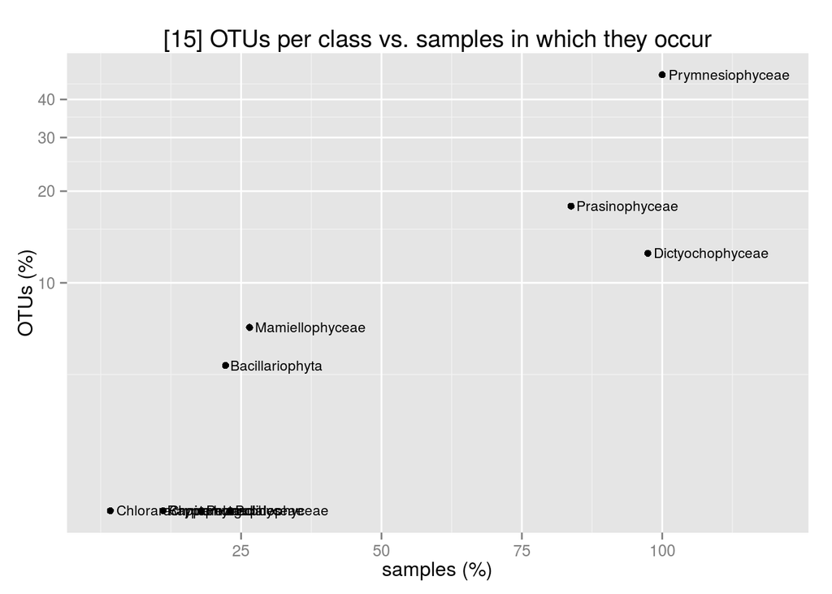

Reads per class vs. OTUs per class - PROTISTS [PLOT DESCRIPTION]

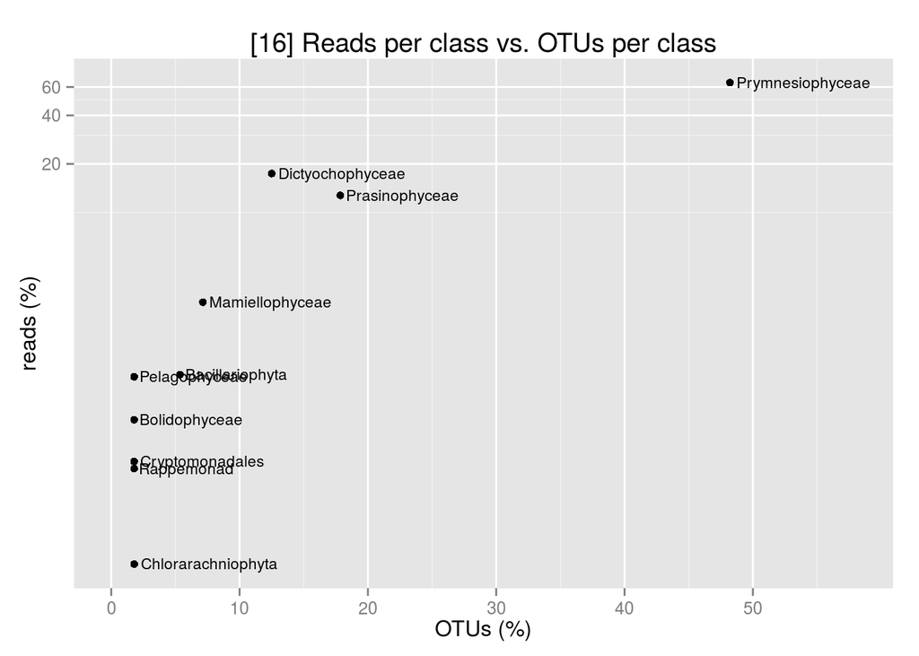

OTUs per class vs. samples in which they occur - PROTISTS vs. CYANOBACTERIA [PLOT DESCRIPTION]

```
##   reads_per_class    OTUs_per_class samples_per_class
##          100.0000          100.0000          494.8718
```

```
##                    reads_per_class OTUs_per_class samples_per_class
## Prymnesiophyceae       1.147720112      31.034483        100.000000
## Dictyochophyceae       0.313071574       8.045977         97.435897
## Prasinophyceae         0.229160869      11.494253         83.760684
## Mamiellophyceae        0.049879672       4.597701         26.495726
## Bacillariophyta        0.017729576       3.448276         22.222222
## Pelagophyceae          0.017172261       1.149425         17.948718
## Bolidophyceae          0.009300190       1.149425         23.076923
## Cryptomonadales        0.005120329       1.149425         11.111111
## Rappemonad             0.004632679       1.149425         11.111111
## Chlorarachniophyta     0.001184294       1.149425          1.709402
## Cyanobacteria         98.205028442      35.632184        100.000000
```

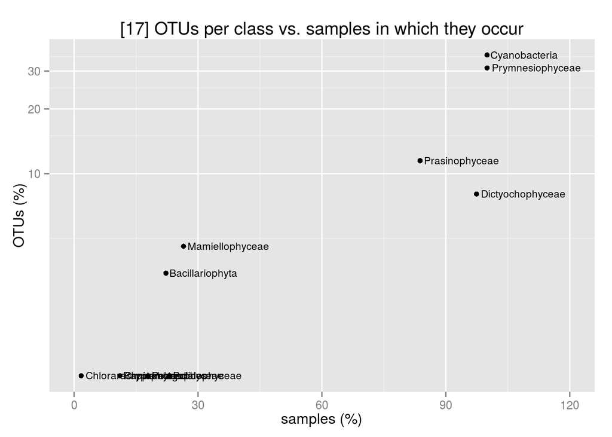

Reads per class vs. OTUs per class - PROTISTS vs CYANOBACTERIA [PLOT DESCRIPTION]

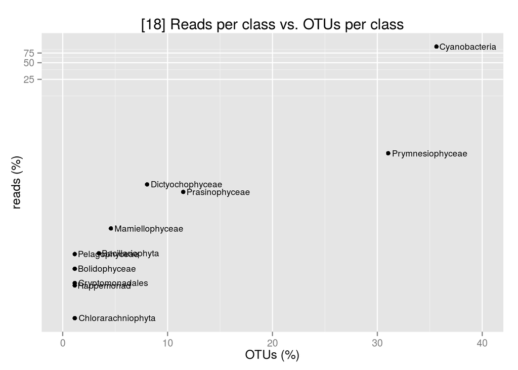